# ASSIGNMENT 3

## 7.Encoding

Convert the strings into numerical or binary format

1.Nominal Encoding :If varaible is not worried the about arrangement of data i)one hot encoding ii)one hot encoding with many categorical variables iii)mean encoding

2.Ordinal Encoding : Take care about the rank of the data i)label encoding ii)Target guided ordinal encoding

#### Label Encoding on Sex

Label encoding on Sex because there are only two values(two categories: male and female) for sex column which can be labeled as 0 & 1

```python
from sklearn.preprocessing import LabelEncoder
```

```python
l=LabelEncoder()
```

```python
x["Sex"]=l.fit_transform(x["Sex"])
x["Sex"]
```

```
0      1
1      0
2      0
3      0
4      1
      ..
886    1
887    0
888    0
889    1
890    1
Name: Sex, Length: 882, dtype: int32
```

```python
x.head()
```

|  | PassengerId | Pclass | Name | Sex | Age | SibSp | Parch | Ticket | Fare | Cabin | Embarked |
| --- | --- | --- | --- | --- | --- | --- | --- | --- | --- | --- | --- |
| 0 | 1 | 3 | Braund, Mr. Owen Harris | 1 | 22.0 | 1 | 0 | A/5 21171 | 7.2500 | B96 B98 | S |
| 1 | 2 | 1 | Cumings, Mrs. John Bradley (Florence Briggs Th... | 0 | 38.0 | 1 | 0 | PC 17599 | 14.4542 | C85 | C |
| 2 | 3 | 3 | Heikkinen, Miss. Laina | 0 | 26.0 | 0 | 0 | STON/O2. 3101282 | 7.9250 | B96 B98 | S |
| 3 | 4 | 1 | Futrelle, Mrs. Jacques Heath (Lily May Peel) | 0 | 35.0 | 1 | 0 | 113803 | 53.1000 | C123 | S |
| 4 | 5 | 3 | Allen, Mr. William Henry | 1 | 35.0 | 0 | 0 | 373450 | 8.0500 | B96 B98 | S |

```python
x["Sex"].value_counts()
```

```
1    573
0    309
Name: Sex, dtype: int64
```

```python
x["Sex"].nunique()
```

```
2
```

#### Label Encoding on Embarked, Cabin & Ticket

```python
x["Embarked"]=l.fit_transform(x["Embarked"])
x["Embarked"]
```

```
0      2
1      0
2      2
3      2
4      2
      ..
886    2
887    2
888    2
889    0
890    1
Name: Embarked, Length: 882, dtype: int32
```

```python
x["Embarked"].value_counts()
```

```
2    643
0    162
1     77
Name: Embarked, dtype: int64
```

```python
x["Embarked"].nunique()
```

```
3
```

```python
x.head()
```

|  | PassengerId | Pclass | Name | Sex | Age | SibSp | Parch | Ticket | Fare | Cabin | Embarked |
| --- | --- | --- | --- | --- | --- | --- | --- | --- | --- | --- | --- |
| 0 | 1 | 3 | Braund, Mr. Owen Harris | 1 | 22.0 | 1 | 0 | A/5 21171 | 7.2500 | B96 B98 | 2 |
| 1 | 2 | 1 | Cumings, Mrs. John Bradley (Florence Briggs Th... | 0 | 38.0 | 1 | 0 | PC 17599 | 14.4542 | C85 | 0 |
| 2 | 3 | 3 | Heikkinen, Miss. Laina | 0 | 26.0 | 0 | 0 | STON/O2. 3101282 | 7.9250 | B96 B98 | 2 |
| 3 | 4 | 1 | Futrelle, Mrs. Jacques Heath (Lily May Peel) | 0 | 35.0 | 1 | 0 | 113803 | 53.1000 | C123 | 2 |
| 4 | 5 | 3 | Allen, Mr. William Henry | 1 | 35.0 | 0 | 0 | 373450 | 8.0500 | B96 B98 | 2 |

```python
x["Ticket"]=l.fit_transform(x["Ticket"])
x["Ticket"]
```

```
0      520
1      592
2      663
3       47
4      469
      ...
886     99
887     13
888    669
889      7
890    463
Name: Ticket, Length: 882, dtype: int32
```

```python
x["Cabin"]=l.fit_transform(x["Cabin"])
x["Cabin"]
```

```
0      45
1      79
2      45
3      53
4      45
       ..
886    45
887    28
888    45
889    58
890    45
Name: Cabin, Length: 882, dtype: int32
```

```python
x["Name"]=l.fit_transform(x["Name"])
x["Name"]
```

```
0      108
1      189
2      351
3      271
4       15
      ...
886    542
887    302
888    407
889     81
890    219
Name: Name, Length: 882, dtype: int32
```

```python
x
```

|  | PassengerId | Pclass | Name | Sex | Age | SibSp | Parch | Ticket | Fare | Cabin | Embarked |
| --- | --- | --- | --- | --- | --- | --- | --- | --- | --- | --- | --- |
| 0 | 1 | 3 | 108 | 1 | 22.000000 | 1 | 0 | 520 | 7.2500 | 45 | 2 |
| 1 | 2 | 1 | 189 | 0 | 38.000000 | 1 | 0 | 592 | 14.4542 | 79 | 0 |
| 2 | 3 | 3 | 351 | 0 | 26.000000 | 0 | 0 | 663 | 7.9250 | 45 | 2 |
| 3 | 4 | 1 | 271 | 0 | 35.000000 | 1 | 0 | 47 | 53.1000 | 53 | 2 |
| 4 | 5 | 3 | 15 | 1 | 35.000000 | 0 | 0 | 469 | 8.0500 | 45 | 2 |
| ... | ... | ... | ... | ... | ... | ... | ... | ... | ... | ... | ... |
| 886 | 887 | 2 | 542 | 1 | 27.000000 | 0 | 0 | 99 | 13.0000 | 45 | 2 |
| 887 | 888 | 1 | 302 | 0 | 19.000000 | 0 | 0 | 13 | 30.0000 | 28 | 2 |
| 888 | 889 | 3 | 407 | 0 | 29.699118 | 1 | 2 | 669 | 23.4500 | 45 | 2 |
| 889 | 890 | 1 | 81 | 1 | 26.000000 | 0 | 0 | 7 | 30.0000 | 58 | 0 |
| 890 | 891 | 3 | 219 | 1 | 32.000000 | 0 | 0 | 463 | 7.7500 | 45 | 1 |

882 rows × 11 columns

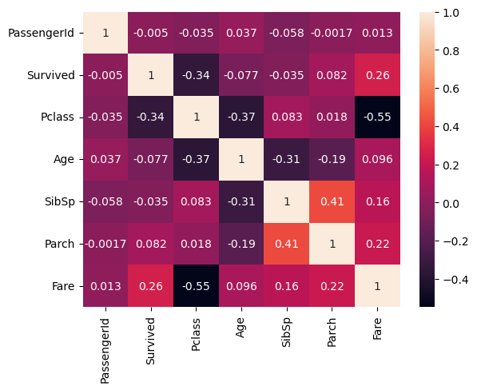

```python
sns.heatmap(corr,annot=True)
```

## 8.Splitting into training set and testing set

We have training and testting data

example: 1000 rows

```
Training data : 70%-80%

Testing data  : 20%-30% (checking performance)
```

```python
from sklearn.model_selection import train_test_split
x_train,x_test,y_train,y_test=train_test_split(x,y,test_size=0.3,random_state=0)
```

```python
x_train.shape,x_test.shape,y_train.shape,y_test.shape
```

```
((617, 11), (265, 11), (617, 1), (265, 1))
```

## 9.Feature Scaling

Feature Scaling is a technique to standardize the independent features present in the data in a fixed range. It is performed during the data pre-processing to handle highly varying magnitudes or values or units. If feature scaling is not done, then a machine learning algorithm tends to weigh greater values, higher and consider smaller values as the lower values, regardless of the unit of the values.

Its only done on independent varaibles because with change in independent variables the magnitude will change.Which will indirectly change dependent variables.

2 Types:

Standard scaling => mean=0 && sd=1

min max scaling => range from 0 to 1

```python
from sklearn.preprocessing import StandardScaler
sc=StandardScaler()
```

```python
x_train=sc.fit_transform(x_train)
x_test=sc.fit_transform(x_test)
```

```python
x_train
```

```
array([[-1.6948399 ,  0.85675649,  1.09700401, ..., -0.76182423,
        -0.29079717,  0.59293918],
       [-1.113136  , -0.33921354,  1.55529655, ..., -0.1248214 ,
        -0.29079717,  0.59293918],
       [-1.23416164,  0.85675649, -0.83326203, ..., -0.77458083,
        -0.29079717, -1.93011926],
       ...,
       [ 0.74519324, -0.33921354, -1.03522145, ...,  0.74381884,
        -0.29079717,  0.59293918],
       [ 0.46800547,  0.85675649,  1.31838261, ..., -0.77458083,
        -0.29079717,  0.59293918],
       [ 0.95991616,  0.85675649,  0.02894936, ...,  3.24598252,
        -0.29079717,  0.59293918]])
```